# Risk Factor Analysis

## Outcome Variable

**Outcome Variable:** y_rate_len

## Predictor Variables

**Intervention Variable:** fhtcm

**Adjustment Set:**

- arm
- W_mage
- W_fage
- meducyrs
- feducyrs
- W_mhtcm
- W_mwtkg
- W_mbmi
- single
- delta_W_fage
- delta_meducyrs
- delta_feducyrs
- delta_W_mhtcm
- delta_W_mwtkg
- delta_W_mbmi
- delta_single

## Stratifying Variables

The analysis was stratified on these variable(s):

- agecat
- studyid
- country

## Data Summary

| agecat | studyid | country | fhtcm | n_cell | n | outcome_variable |
| --- | --- | --- | --- | --- | --- | --- |
| 0-3 months | ki1000304b-SAS-CompFeed | INDIA | >=167 cm | 345 | 765 | y_rate_len |
| 0-3 months | ki1000304b-SAS-CompFeed | INDIA | <162 cm | 196 | 765 | y_rate_len |
| 0-3 months | ki1000304b-SAS-CompFeed | INDIA | [162-167) cm | 224 | 765 | y_rate_len |
| 0-3 months | ki1101329-Keneba | GAMBIA | >=167 cm | 631 | 965 | y_rate_len |
| 0-3 months | ki1101329-Keneba | GAMBIA | <162 cm | 75 | 965 | y_rate_len |
| 0-3 months | ki1101329-Keneba | GAMBIA | [162-167) cm | 259 | 965 | y_rate_len |
| 0-3 months | ki1119695-PROBIT | BELARUS | >=167 cm | 10773 | 11500 | y_rate_len |
| 0-3 months | ki1119695-PROBIT | BELARUS | <162 cm | 151 | 11500 | y_rate_len |
| 0-3 months | ki1119695-PROBIT | BELARUS | [162-167) cm | 576 | 11500 | y_rate_len |
| 0-3 months | ki1135781-COHORTS | GUATEMALA | >=167 cm | 25 | 180 | y_rate_len |
| 0-3 months | ki1135781-COHORTS | GUATEMALA | <162 cm | 106 | 180 | y_rate_len |
| 0-3 months | ki1135781-COHORTS | GUATEMALA | [162-167) cm | 49 | 180 | y_rate_len |
| 3-6 months | ki1000304b-SAS-CompFeed | INDIA | >=167 cm | 308 | 682 | y_rate_len |
| 3-6 months | ki1000304b-SAS-CompFeed | INDIA | <162 cm | 175 | 682 | y_rate_len |
| 3-6 months | ki1000304b-SAS-CompFeed | INDIA | [162-167) cm | 199 | 682 | y_rate_len |
| 3-6 months | ki1101329-Keneba | GAMBIA | >=167 cm | 673 | 1037 | y_rate_len |
| 3-6 months | ki1101329-Keneba | GAMBIA | <162 cm | 74 | 1037 | y_rate_len |
| 3-6 months | ki1101329-Keneba | GAMBIA | [162-167) cm | 290 | 1037 | y_rate_len |
| 3-6 months | ki1119695-PROBIT | BELARUS | >=167 cm | 9473 | 10104 | y_rate_len |
| 3-6 months | ki1119695-PROBIT | BELARUS | <162 cm | 129 | 10104 | y_rate_len |
| 3-6 months | ki1119695-PROBIT | BELARUS | [162-167) cm | 502 | 10104 | y_rate_len |
| 3-6 months | ki1135781-COHORTS | GUATEMALA | >=167 cm | 37 | 261 | y_rate_len |
| 3-6 months | ki1135781-COHORTS | GUATEMALA | <162 cm | 148 | 261 | y_rate_len |
| 3-6 months | ki1135781-COHORTS | GUATEMALA | [162-167) cm | 76 | 261 | y_rate_len |
| 6-9 months | ki1000304b-SAS-CompFeed | INDIA | >=167 cm | 312 | 683 | y_rate_len |
| 6-9 months | ki1000304b-SAS-CompFeed | INDIA | <162 cm | 167 | 683 | y_rate_len |
| 6-9 months | ki1000304b-SAS-CompFeed | INDIA | [162-167) cm | 204 | 683 | y_rate_len |
| 6-9 months | ki1000304b-SAS-FoodSuppl | INDIA | >=167 cm | 89 | 311 | y_rate_len |
| 6-9 months | ki1000304b-SAS-FoodSuppl | INDIA | <162 cm | 124 | 311 | y_rate_len |
| 6-9 months | ki1000304b-SAS-FoodSuppl | INDIA | [162-167) cm | 98 | 311 | y_rate_len |

[output cut: 72 more lines]

The following strata were considered:

- agecat: 0-3 months, studyid: ki1000304b-SAS-CompFeed, country: INDIA
- agecat: 0-3 months, studyid: ki1101329-Keneba, country: GAMBIA
- agecat: 0-3 months, studyid: ki1119695-PROBIT, country: BELARUS
- agecat: 0-3 months, studyid: ki1135781-COHORTS, country: GUATEMALA
- agecat: 12-15 months, studyid: ki1000304b-SAS-CompFeed, country: INDIA
- agecat: 12-15 months, studyid: ki1000304b-SAS-FoodSuppl, country: INDIA
- agecat: 12-15 months, studyid: ki1101329-Keneba, country: GAMBIA
- agecat: 12-15 months, studyid: ki1119695-PROBIT, country: BELARUS
- agecat: 12-15 months, studyid: ki1135781-COHORTS, country: GUATEMALA
- agecat: 15-18 months, studyid: ki1000304b-SAS-CompFeed, country: INDIA
- agecat: 15-18 months, studyid: ki1000304b-SAS-FoodSuppl, country: INDIA
- agecat: 15-18 months, studyid: ki1101329-Keneba, country: GAMBIA
- agecat: 15-18 months, studyid: ki1119695-PROBIT, country: BELARUS
- agecat: 15-18 months, studyid: ki1135781-COHORTS, country: GUATEMALA
- agecat: 18-21 months, studyid: ki1101329-Keneba, country: GAMBIA
- agecat: 18-21 months, studyid: ki1119695-PROBIT, country: BELARUS
- agecat: 18-21 months, studyid: ki1135781-COHORTS, country: GUATEMALA
- agecat: 21-24 months, studyid: ki1101329-Keneba, country: GAMBIA
- agecat: 21-24 months, studyid: ki1119695-PROBIT, country: BELARUS
- agecat: 21-24 months, studyid: ki1135781-COHORTS, country: GUATEMALA
- agecat: 3-6 months, studyid: ki1000304b-SAS-CompFeed, country: INDIA
- agecat: 3-6 months, studyid: ki1101329-Keneba, country: GAMBIA
- agecat: 3-6 months, studyid: ki1119695-PROBIT, country: BELARUS
- agecat: 3-6 months, studyid: ki1135781-COHORTS, country: GUATEMALA
- agecat: 6-9 months, studyid: ki1000304b-SAS-CompFeed, country: INDIA
- agecat: 6-9 months, studyid: ki1000304b-SAS-FoodSuppl, country: INDIA
- agecat: 6-9 months, studyid: ki1101329-Keneba, country: GAMBIA
- agecat: 6-9 months, studyid: ki1119695-PROBIT, country: BELARUS
- agecat: 6-9 months, studyid: ki1135781-COHORTS, country: GUATEMALA
- agecat: 9-12 months, studyid: ki1000304b-SAS-CompFeed, country: INDIA
- agecat: 9-12 months, studyid: ki1000304b-SAS-FoodSuppl, country: INDIA
- agecat: 9-12 months, studyid: ki1101329-Keneba, country: GAMBIA
- agecat: 9-12 months, studyid: ki1119695-PROBIT, country: BELARUS
- agecat: 9-12 months, studyid: ki1135781-COHORTS, country: GUATEMALA

### Dropped Strata

Some strata were dropped due to rare outcomes:

- agecat: 15-18 months, studyid: ki1119695-PROBIT, country: BELARUS
- agecat: 18-21 months, studyid: ki1119695-PROBIT, country: BELARUS
- agecat: 21-24 months, studyid: ki1119695-PROBIT, country: BELARUS

## Methods Detail

We’re interested in the causal parameters $E[Y_a]$ for all values of $a \in \mathcal{A}$. These parameters represent the mean outcome if, possibly contrary to fact, we intervened to set all units to have $A=a$. Under the randomization and positivity assumptions, these are identified by the statistical parameters $\psi_a=E_W[E_{Y|A,W}(Y|A=a,W)]$. In addition, we’re interested in the mean of $Y$, $E[Y]$ under no intervention (the observed mean). We will estimate these parameters by using SuperLearner to fit the relevant likelihood factors – $E_{Y|A,W}(Y|A=a,W)$ and $p(A=a|W)$, and then updating our likelihood fit using a joint TMLE.

For unadjusted analyses ($W=\{\}$), initial likelihoods were estimated using Lrnr_glm to estimate the simple $E(Y|A)$ and Lrnr_mean to estimate $p(A)$. For adjusted analyses, a small library containing Lrnr_glmnet, Lrnr_xgboost, and Lrnr_mean was used.

Having estimated these parameters, we will then use the delta method to estimate relative risks and attributable risks relative to a prespecified baseline level of $A$.

# Results Detail

## Results Plots

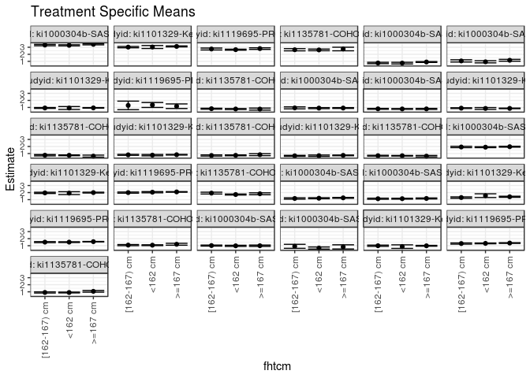

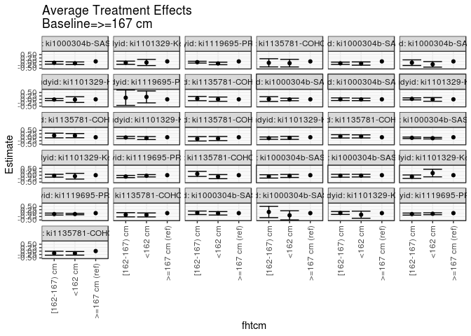

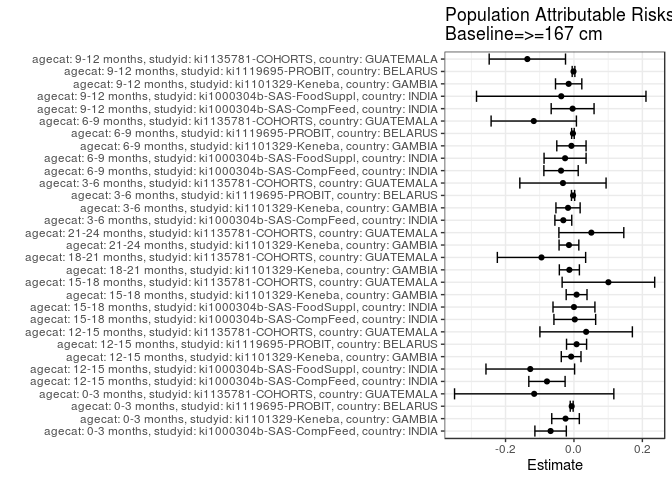

## Results Table

### Parameter: TSM

| agecat | studyid | country | intervention_level | baseline_level | estimate | ci_lower | ci_upper |
| --- | --- | --- | --- | --- | --- | --- | --- |
| 0-3 months | ki1000304b-SAS-CompFeed | INDIA | >=167 cm | NA | 3.4131819 | 3.3387104 | 3.4876534 |
| 0-3 months | ki1000304b-SAS-CompFeed | INDIA | <162 cm | NA | 3.2753311 | 3.1960988 | 3.3545634 |
| 0-3 months | ki1000304b-SAS-CompFeed | INDIA | [162-167) cm | NA | 3.3121954 | 3.2171680 | 3.4072227 |
| 0-3 months | ki1101329-Keneba | GAMBIA | >=167 cm | NA | 3.1190269 | 3.0487188 | 3.1893349 |
| 0-3 months | ki1101329-Keneba | GAMBIA | <162 cm | NA | 3.0386533 | 2.8260500 | 3.2512565 |
| 0-3 months | ki1101329-Keneba | GAMBIA | [162-167) cm | NA | 3.0202751 | 2.9257198 | 3.1148304 |
| 0-3 months | ki1119695-PROBIT | BELARUS | >=167 cm | NA | 2.8104801 | 2.6992151 | 2.9217451 |
| 0-3 months | ki1119695-PROBIT | BELARUS | <162 cm | NA | 2.6595079 | 2.5915706 | 2.7274451 |
| 0-3 months | ki1119695-PROBIT | BELARUS | [162-167) cm | NA | 2.7530423 | 2.6161608 | 2.8899237 |
| 0-3 months | ki1135781-COHORTS | GUATEMALA | >=167 cm | NA | 2.7515972 | 2.4983463 | 3.0048480 |
| 0-3 months | ki1135781-COHORTS | GUATEMALA | <162 cm | NA | 2.6218762 | 2.5034713 | 2.7402811 |
| 0-3 months | ki1135781-COHORTS | GUATEMALA | [162-167) cm | NA | 2.6468846 | 2.4888517 | 2.8049176 |
| 3-6 months | ki1000304b-SAS-CompFeed | INDIA | >=167 cm | NA | 1.9692092 | 1.9027048 | 2.0357136 |
| 3-6 months | ki1000304b-SAS-CompFeed | INDIA | <162 cm | NA | 1.9015391 | 1.8345291 | 1.9685490 |
| 3-6 months | ki1000304b-SAS-CompFeed | INDIA | [162-167) cm | NA | 1.9284971 | 1.8349533 | 2.0220410 |
| 3-6 months | ki1101329-Keneba | GAMBIA | >=167 cm | NA | 1.9967805 | 1.9412706 | 2.0522903 |
| 3-6 months | ki1101329-Keneba | GAMBIA | <162 cm | NA | 1.9222280 | 1.7194533 | 2.1250028 |
| 3-6 months | ki1101329-Keneba | GAMBIA | [162-167) cm | NA | 1.9571128 | 1.8691426 | 2.0450829 |
| 3-6 months | ki1119695-PROBIT | BELARUS | >=167 cm | NA | 2.0942522 | 2.0529386 | 2.1355657 |
| 3-6 months | ki1119695-PROBIT | BELARUS | <162 cm | NA | 2.0515499 | 1.9641048 | 2.1389949 |
| 3-6 months | ki1119695-PROBIT | BELARUS | [162-167) cm | NA | 1.9969557 | 1.9189847 | 2.0749267 |
| 3-6 months | ki1135781-COHORTS | GUATEMALA | >=167 cm | NA | 1.8301673 | 1.6947043 | 1.9656303 |
| 3-6 months | ki1135781-COHORTS | GUATEMALA | <162 cm | NA | 1.7247152 | 1.6540198 | 1.7954106 |
| 3-6 months | ki1135781-COHORTS | GUATEMALA | [162-167) cm | NA | 1.9251356 | 1.7933611 | 2.0569101 |
| 6-9 months | ki1000304b-SAS-CompFeed | INDIA | >=167 cm | NA | 1.2522181 | 1.1959672 | 1.3084690 |
| 6-9 months | ki1000304b-SAS-CompFeed | INDIA | <162 cm | NA | 1.1969259 | 1.1245786 | 1.2692733 |
| 6-9 months | ki1000304b-SAS-CompFeed | INDIA | [162-167) cm | NA | 1.1630760 | 1.0655611 | 1.2605909 |
| 6-9 months | ki1000304b-SAS-FoodSuppl | INDIA | >=167 cm | NA | 1.1664626 | 1.0982159 | 1.2347093 |
| 6-9 months | ki1000304b-SAS-FoodSuppl | INDIA | <162 cm | NA | 1.1337563 | 1.0660554 | 1.2014572 |
| 6-9 months | ki1000304b-SAS-FoodSuppl | INDIA | [162-167) cm | NA | 1.1258016 | 1.0483134 | 1.2032898 |

[output cut: 63 more lines]

### Parameter: E(Y)

| agecat | studyid | country | intervention_level | baseline_level | estimate | ci_lower | ci_upper |
| --- | --- | --- | --- | --- | --- | --- | --- |
| 0-3 months | ki1000304b-SAS-CompFeed | INDIA | NA | NA | 3.3449470 | 3.2851675 | 3.4047265 |
| 0-3 months | ki1101329-Keneba | GAMBIA | NA | NA | 3.0944274 | 3.0398727 | 3.1489822 |
| 0-3 months | ki1119695-PROBIT | BELARUS | NA | NA | 2.8038915 | 2.6921727 | 2.9156104 |
| 0-3 months | ki1135781-COHORTS | GUATEMALA | NA | NA | 2.6353712 | 2.5465302 | 2.7242122 |
| 3-6 months | ki1000304b-SAS-CompFeed | INDIA | NA | NA | 1.9381168 | 1.8722991 | 2.0039344 |
| 3-6 months | ki1101329-Keneba | GAMBIA | NA | NA | 1.9794873 | 1.9347361 | 2.0242384 |
| 3-6 months | ki1119695-PROBIT | BELARUS | NA | NA | 2.0916969 | 2.0506004 | 2.1327933 |
| 3-6 months | ki1135781-COHORTS | GUATEMALA | NA | NA | 1.7979953 | 1.7423030 | 1.8536877 |
| 6-9 months | ki1000304b-SAS-CompFeed | INDIA | NA | NA | 1.2144768 | 1.1795030 | 1.2494506 |
| 6-9 months | ki1000304b-SAS-FoodSuppl | INDIA | NA | NA | 1.1405137 | 1.0997387 | 1.1812887 |
| 6-9 months | ki1101329-Keneba | GAMBIA | NA | NA | 1.3966930 | 1.3370412 | 1.4563449 |
| 6-9 months | ki1119695-PROBIT | BELARUS | NA | NA | 1.5712042 | 1.5417439 | 1.6006645 |
| 6-9 months | ki1135781-COHORTS | GUATEMALA | NA | NA | 1.0891323 | 1.0450915 | 1.1331731 |
| 9-12 months | ki1000304b-SAS-CompFeed | INDIA | NA | NA | 0.9930838 | 0.9436059 | 1.0425616 |
| 9-12 months | ki1000304b-SAS-FoodSuppl | INDIA | NA | NA | 0.7916715 | 0.6618281 | 0.9215150 |
| 9-12 months | ki1101329-Keneba | GAMBIA | NA | NA | 0.9708891 | 0.9222915 | 1.0194866 |
| 9-12 months | ki1119695-PROBIT | BELARUS | NA | NA | 1.3756313 | 1.3222614 | 1.4290012 |
| 9-12 months | ki1135781-COHORTS | GUATEMALA | NA | NA | 0.9293038 | 0.8874492 | 0.9711585 |
| 12-15 months | ki1000304b-SAS-CompFeed | INDIA | NA | NA | 0.8285766 | 0.7562994 | 0.9008539 |
| 12-15 months | ki1000304b-SAS-FoodSuppl | INDIA | NA | NA | 1.0258822 | 0.9363066 | 1.1154578 |
| 12-15 months | ki1101329-Keneba | GAMBIA | NA | NA | 0.9309324 | 0.8952046 | 0.9666602 |
| 12-15 months | ki1119695-PROBIT | BELARUS | NA | NA | 1.1801864 | 0.8594720 | 1.5009008 |
| 12-15 months | ki1135781-COHORTS | GUATEMALA | NA | NA | 0.8018513 | 0.7601969 | 0.8435058 |
| 15-18 months | ki1000304b-SAS-CompFeed | INDIA | NA | NA | 0.9190004 | 0.8846761 | 0.9533247 |
| 15-18 months | ki1000304b-SAS-FoodSuppl | INDIA | NA | NA | 0.7935645 | 0.7577956 | 0.8293333 |
| 15-18 months | ki1101329-Keneba | GAMBIA | NA | NA | 0.8726682 | 0.8384641 | 0.9068722 |
| 15-18 months | ki1135781-COHORTS | GUATEMALA | NA | NA | 0.7314958 | 0.6886307 | 0.7743608 |
| 18-21 months | ki1101329-Keneba | GAMBIA | NA | NA | 0.8178809 | 0.7819425 | 0.8538193 |
| 18-21 months | ki1135781-COHORTS | GUATEMALA | NA | NA | 0.7418707 | 0.7002233 | 0.7835182 |
| 21-24 months | ki1101329-Keneba | GAMBIA | NA | NA | 0.7242397 | 0.6859939 | 0.7624856 |
| 21-24 months | ki1135781-COHORTS | GUATEMALA | NA | NA | 0.6767187 | 0.6431305 | 0.7103068 |

### Parameter: ATE

| agecat | studyid | country | intervention_level | baseline_level | estimate | ci_lower | ci_upper |
| --- | --- | --- | --- | --- | --- | --- | --- |
| 0-3 months | ki1000304b-SAS-CompFeed | INDIA | >=167 cm | >=167 cm | 0.0000000 | 0.0000000 | 0.0000000 |
| 0-3 months | ki1000304b-SAS-CompFeed | INDIA | <162 cm | >=167 cm | -0.1378508 | -0.2341221 | -0.0415795 |
| 0-3 months | ki1000304b-SAS-CompFeed | INDIA | [162-167) cm | >=167 cm | -0.1009866 | -0.2002538 | -0.0017193 |
| 0-3 months | ki1101329-Keneba | GAMBIA | >=167 cm | >=167 cm | 0.0000000 | 0.0000000 | 0.0000000 |
| 0-3 months | ki1101329-Keneba | GAMBIA | <162 cm | >=167 cm | -0.0803736 | -0.3046131 | 0.1438659 |
| 0-3 months | ki1101329-Keneba | GAMBIA | [162-167) cm | >=167 cm | -0.0987518 | -0.2166234 | 0.0191199 |
| 0-3 months | ki1119695-PROBIT | BELARUS | >=167 cm | >=167 cm | 0.0000000 | 0.0000000 | 0.0000000 |
| 0-3 months | ki1119695-PROBIT | BELARUS | <162 cm | >=167 cm | -0.1509723 | -0.2423170 | -0.0596276 |
| 0-3 months | ki1119695-PROBIT | BELARUS | [162-167) cm | >=167 cm | -0.0574379 | -0.1239217 | 0.0090459 |
| 0-3 months | ki1135781-COHORTS | GUATEMALA | >=167 cm | >=167 cm | 0.0000000 | 0.0000000 | 0.0000000 |
| 0-3 months | ki1135781-COHORTS | GUATEMALA | <162 cm | >=167 cm | -0.1297210 | -0.4068554 | 0.1474135 |
| 0-3 months | ki1135781-COHORTS | GUATEMALA | [162-167) cm | >=167 cm | -0.1047126 | -0.4031492 | 0.1937241 |
| 3-6 months | ki1000304b-SAS-CompFeed | INDIA | >=167 cm | >=167 cm | 0.0000000 | 0.0000000 | 0.0000000 |
| 3-6 months | ki1000304b-SAS-CompFeed | INDIA | <162 cm | >=167 cm | -0.0676702 | -0.1227230 | -0.0126173 |
| 3-6 months | ki1000304b-SAS-CompFeed | INDIA | [162-167) cm | >=167 cm | -0.0407121 | -0.0983674 | 0.0169432 |
| 3-6 months | ki1101329-Keneba | GAMBIA | >=167 cm | >=167 cm | 0.0000000 | 0.0000000 | 0.0000000 |
| 3-6 months | ki1101329-Keneba | GAMBIA | <162 cm | >=167 cm | -0.0745524 | -0.2848523 | 0.1357474 |
| 3-6 months | ki1101329-Keneba | GAMBIA | [162-167) cm | >=167 cm | -0.0396677 | -0.1443354 | 0.0650000 |
| 3-6 months | ki1119695-PROBIT | BELARUS | >=167 cm | >=167 cm | 0.0000000 | 0.0000000 | 0.0000000 |
| 3-6 months | ki1119695-PROBIT | BELARUS | <162 cm | >=167 cm | -0.0427023 | -0.1268387 | 0.0414341 |
| 3-6 months | ki1119695-PROBIT | BELARUS | [162-167) cm | >=167 cm | -0.0972965 | -0.1777238 | -0.0168692 |
| 3-6 months | ki1135781-COHORTS | GUATEMALA | >=167 cm | >=167 cm | 0.0000000 | 0.0000000 | 0.0000000 |
| 3-6 months | ki1135781-COHORTS | GUATEMALA | <162 cm | >=167 cm | -0.1054521 | -0.2555629 | 0.0446588 |
| 3-6 months | ki1135781-COHORTS | GUATEMALA | [162-167) cm | >=167 cm | 0.0949683 | -0.0927245 | 0.2826612 |
| 6-9 months | ki1000304b-SAS-CompFeed | INDIA | >=167 cm | >=167 cm | 0.0000000 | 0.0000000 | 0.0000000 |
| 6-9 months | ki1000304b-SAS-CompFeed | INDIA | <162 cm | >=167 cm | -0.0552922 | -0.1673165 | 0.0567321 |
| 6-9 months | ki1000304b-SAS-CompFeed | INDIA | [162-167) cm | >=167 cm | -0.0891422 | -0.2100727 | 0.0317884 |
| 6-9 months | ki1000304b-SAS-FoodSuppl | INDIA | >=167 cm | >=167 cm | 0.0000000 | 0.0000000 | 0.0000000 |
| 6-9 months | ki1000304b-SAS-FoodSuppl | INDIA | <162 cm | >=167 cm | -0.0327063 | -0.1290870 | 0.0636744 |
| 6-9 months | ki1000304b-SAS-FoodSuppl | INDIA | [162-167) cm | >=167 cm | -0.0406610 | -0.1442215 | 0.0628995 |

[output cut: 63 more lines]

### Parameter: PAR

| agecat | studyid | country | intervention_level | baseline_level | estimate | ci_lower | ci_upper |
| --- | --- | --- | --- | --- | --- | --- | --- |
| 0-3 months | ki1000304b-SAS-CompFeed | INDIA | >=167 cm | NA | -0.0682349 | -0.1141742 | -0.0222956 |
| 0-3 months | ki1101329-Keneba | GAMBIA | >=167 cm | NA | -0.0245994 | -0.0648832 | 0.0156843 |
| 0-3 months | ki1119695-PROBIT | BELARUS | >=167 cm | NA | -0.0065886 | -0.0108613 | -0.0023159 |
| 0-3 months | ki1135781-COHORTS | GUATEMALA | >=167 cm | NA | -0.1162260 | -0.3490464 | 0.1165945 |
| 3-6 months | ki1000304b-SAS-CompFeed | INDIA | >=167 cm | NA | -0.0310924 | -0.0557338 | -0.0064511 |
| 3-6 months | ki1101329-Keneba | GAMBIA | >=167 cm | NA | -0.0172932 | -0.0526463 | 0.0180599 |
| 3-6 months | ki1119695-PROBIT | BELARUS | >=167 cm | NA | -0.0025553 | -0.0072196 | 0.0021090 |
| 3-6 months | ki1135781-COHORTS | GUATEMALA | >=167 cm | NA | -0.0321720 | -0.1582243 | 0.0938803 |
| 6-9 months | ki1000304b-SAS-CompFeed | INDIA | >=167 cm | NA | -0.0377414 | -0.0879245 | 0.0124418 |
| 6-9 months | ki1000304b-SAS-FoodSuppl | INDIA | >=167 cm | NA | -0.0259489 | -0.0873747 | 0.0354768 |
| 6-9 months | ki1101329-Keneba | GAMBIA | >=167 cm | NA | -0.0073823 | -0.0501611 | 0.0353965 |
| 6-9 months | ki1119695-PROBIT | BELARUS | >=167 cm | NA | -0.0029587 | -0.0067365 | 0.0008192 |
| 6-9 months | ki1135781-COHORTS | GUATEMALA | >=167 cm | NA | -0.1174823 | -0.2421627 | 0.0071981 |
| 9-12 months | ki1000304b-SAS-CompFeed | INDIA | >=167 cm | NA | -0.0038909 | -0.0665586 | 0.0587768 |
| 9-12 months | ki1000304b-SAS-FoodSuppl | INDIA | >=167 cm | NA | -0.0371375 | -0.2848035 | 0.2105285 |
| 9-12 months | ki1101329-Keneba | GAMBIA | >=167 cm | NA | -0.0154666 | -0.0539079 | 0.0229748 |
| 9-12 months | ki1119695-PROBIT | BELARUS | >=167 cm | NA | -0.0012440 | -0.0051770 | 0.0026891 |
| 9-12 months | ki1135781-COHORTS | GUATEMALA | >=167 cm | NA | -0.1362156 | -0.2477875 | -0.0246437 |
| 12-15 months | ki1000304b-SAS-CompFeed | INDIA | >=167 cm | NA | -0.0788981 | -0.1319321 | -0.0258641 |
| 12-15 months | ki1000304b-SAS-FoodSuppl | INDIA | >=167 cm | NA | -0.1276557 | -0.2571770 | 0.0018655 |
| 12-15 months | ki1101329-Keneba | GAMBIA | >=167 cm | NA | -0.0082170 | -0.0370397 | 0.0206057 |
| 12-15 months | ki1119695-PROBIT | BELARUS | >=167 cm | NA | 0.0076338 | -0.0216943 | 0.0369618 |
| 12-15 months | ki1135781-COHORTS | GUATEMALA | >=167 cm | NA | 0.0356302 | -0.0995169 | 0.1707773 |
| 15-18 months | ki1000304b-SAS-CompFeed | INDIA | >=167 cm | NA | 0.0024497 | -0.0585477 | 0.0634471 |
| 15-18 months | ki1000304b-SAS-FoodSuppl | INDIA | >=167 cm | NA | 0.0000218 | -0.0612404 | 0.0612841 |
| 15-18 months | ki1101329-Keneba | GAMBIA | >=167 cm | NA | 0.0077309 | -0.0227051 | 0.0381669 |
| 15-18 months | ki1135781-COHORTS | GUATEMALA | >=167 cm | NA | 0.1007152 | -0.0345656 | 0.2359961 |
| 18-21 months | ki1101329-Keneba | GAMBIA | >=167 cm | NA | -0.0134119 | -0.0427337 | 0.0159100 |
| 18-21 months | ki1135781-COHORTS | GUATEMALA | >=167 cm | NA | -0.0948829 | -0.2239425 | 0.0341767 |
| 21-24 months | ki1101329-Keneba | GAMBIA | >=167 cm | NA | -0.0146332 | -0.0435200 | 0.0142535 |
| 21-24 months | ki1135781-COHORTS | GUATEMALA | >=167 cm | NA | 0.0508596 | -0.0439991 | 0.1457183 |